# MiCM: 01 - DESeq2

2025-10-23

[figure not shown]

This session will guide you to use DESeq2 to identify differentially expressed genes and become familiar with design matrices. The session will also introduce concepts essential for working with real-world data, such as incorporating covariates and interaction terms into models.

The objectives of this session are:

- Obtain familiarity with the DESeq2 workflow
- Design and configure differential expression models appropriately for RNA-seq data

**Note**: All the code in this tutorial will be performed in R (or Rstudio).

# Dataset

This workshop will use processed RNA-seq counts from this [study](https://doi.org/10.1016/j.stem.2021.04.028), where they studied the transcriptional response to SARS-CoV-2 infection in three tissues (cornea, limbus, sclera). The dataset consists of 18 samples, with three replicates per tissue and condition (mock vs CoV-2).

The data can be found here:

```bash
ls ../data/
```

```
c2.cp.kegg_legacy.v2025.1.Hs.symbols.gmt
GSE164073_Eye_count_matrix.tsv
GSE164073_Eye_count_meta.tsv
h.all.v2025.1.Hs.symbols.gmt
res_Cornea_CoV2_vs_Mock.rds
```

# DEseq2 workflow

## Load libraries

```r
library(DESeq2)
library(vsn) # Used for standard deviation vs mean plots
library(hexbin) # Used for standard deviation vs mean plots
library(pheatmap)
library(RColorBrewer)
library(EnhancedVolcano)
library(ggplot2)
library(ggbeeswarm)
library(ashr) # Used for log-fold shrinkage
library(knitr) # Used for formatting output
```

## Load the data

Let’s load the dataset that consists of a raw count matrix and a metadata.

```r
raw_counts<- read.table("../data/GSE164073_Eye_count_matrix.tsv", header=T, row.names=1)
meta<- read.table("../data/GSE164073_Eye_count_meta.tsv", row.names=1)
kable(head(raw_counts[,1:5]))
```

|  | MW1 | MW2 | MW3 | MW4 | MW5 |
| --- | --- | --- | --- | --- | --- |
| A1BG | 91 | 131 | 86 | 77 | 69 |
| A1BG-AS1 | 292 | 284 | 271 | 232 | 250 |
| A1CF | 0 | 0 | 0 | 0 | 0 |
| A2M | 255 | 273 | 263 | 150 | 176 |
| A2M-AS1 | 8 | 9 | 9 | 11 | 16 |
| A2ML1 | 0 | 0 | 0 | 0 | 0 |

```r
kable(head(meta))
```

|  | Tissue | Condition |
| --- | --- | --- |
| MW1 | cornea | mock |
| MW2 | cornea | mock |
| MW3 | cornea | mock |
| MW4 | cornea | CoV2 |
| MW5 | cornea | CoV2 |
| MW6 | cornea | CoV2 |

## Create DESeq2 object

The first step is to create a design matrix. Let’s start by creating a very simple design matrix.

```r
# Converting Tissue into a factor
meta$Tissue<- factor(meta$Tissue)
# Adjusting levels for Condition, so that mock is the reference
meta$Condition<- factor(meta$Condition, levels=c("mock", "CoV2"))
meta_design<- model.matrix( ~ Condition, data=meta)
kable(head(meta_design))
```

|  | (Intercept) | ConditionCoV2 |
| --- | --- | --- |
| MW1 | 1 | 0 |
| MW2 | 1 | 0 |
| MW3 | 1 | 0 |
| MW4 | 1 | 1 |
| MW5 | 1 | 1 |
| MW6 | 1 | 1 |

This design matrix is answering the question: What are the overall differences between Mock and CoV2, without considering the tissues?

Now, let’s create a DESeq2 object.

```r
dds <- DESeqDataSetFromMatrix(countData = raw_counts,
                              colData = meta,
                              design= meta_design)
dds
```

```
class: DESeqDataSet
dim: 27946 18
metadata(1): version
assays(1): counts
rownames(27946): A1BG A1BG-AS1 ... ZZEF1 ZZZ3
rowData names(0):
colnames(18): MW1 MW2 ... MW17 MW18
colData names(2): Tissue Condition
```

## Pre-filtering

Removing low expressed counts is generally recommended for memory and speed reasons.

```r
smallestGroupSize <- 3
keep <- rowSums(counts(dds) >= 10) >= smallestGroupSize
dds <- dds[keep,]
dds
```

```
class: DESeqDataSet
dim: 14700 18
metadata(1): version
assays(1): counts
rownames(14700): A1BG A1BG-AS1 ... ZZEF1 ZZZ3
rowData names(0):
colnames(18): MW1 MW2 ... MW17 MW18
colData names(2): Tissue Condition
```

## Quality control

### VST

We can obtain a variance stabilizing transformation

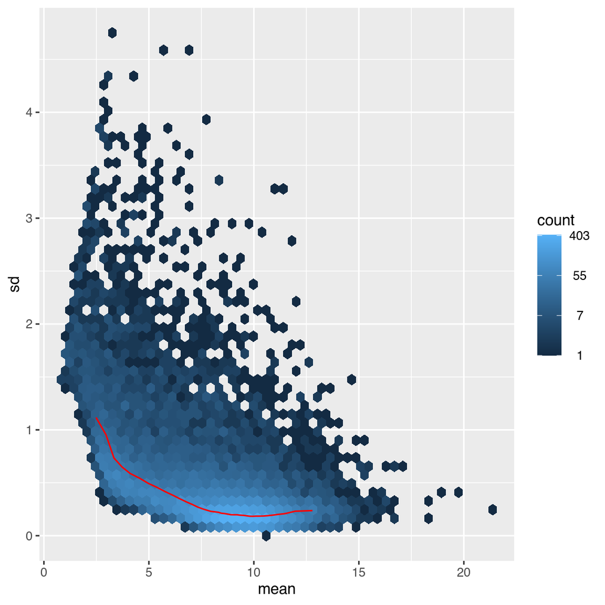

```r
# Obtain the variance stabilizing transformation
vsd <- vst(dds)
# Let's compare it to the normal transformation
ntd <- normTransform(dds)
meanSdPlot(assay(ntd), ranks=F) # Normal
```

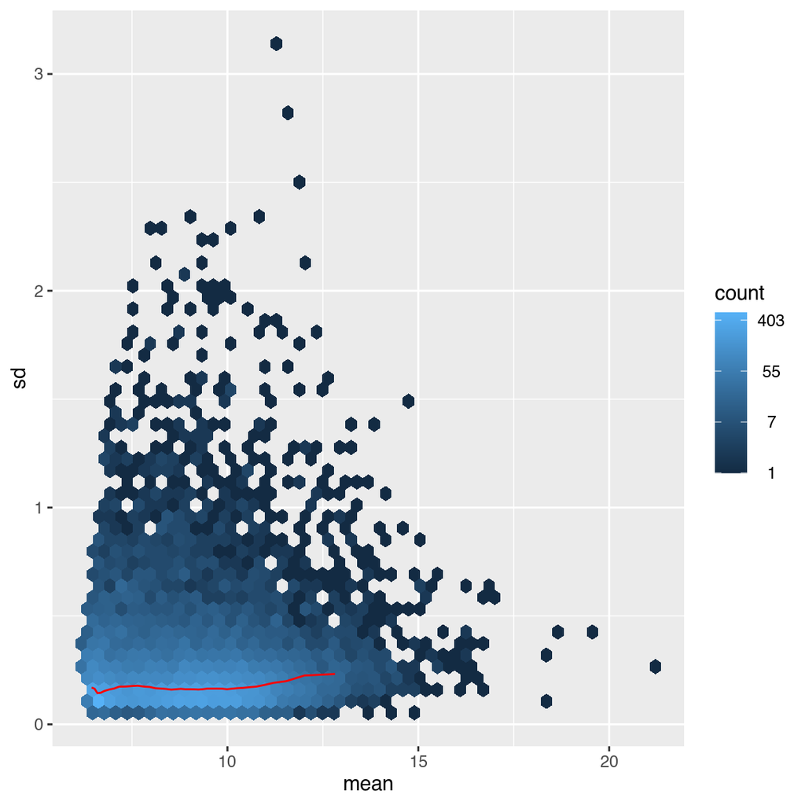

```r
meanSdPlot(assay(vsd), ranks=F) # VST
```

We observe that the vst removes the dependence of the variance on the mean, which is evident for the low expressed genes.

### Heatmap of the sample-to-sample distances

We can obtain distances between samples and then plot them as a heatmap.

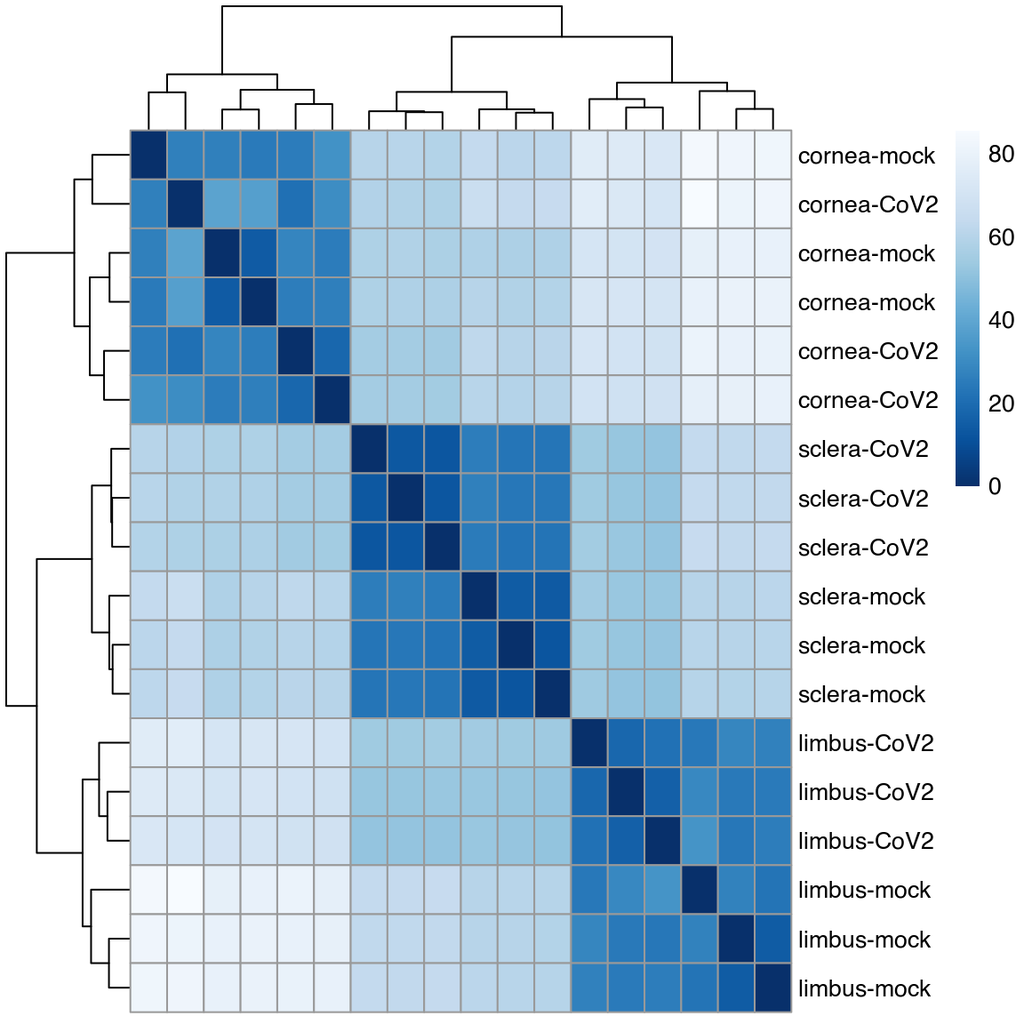

```r
sampleDists <- dist(t(assay(vsd)))
sampleDistMatrix <- as.matrix(sampleDists)
rownames(sampleDistMatrix) <- paste(vsd$Tissue, vsd$Condition, sep="-")
colnames(sampleDistMatrix) <- NULL
colors <- colorRampPalette( rev(brewer.pal(9, "Blues")) )(255)
pheatmap(sampleDistMatrix,
         clustering_distance_rows=sampleDists,
         clustering_distance_cols=sampleDists,
         col=colors)
```

We observe that in general, samples from the same tissue cluster together, as expected.

### Principal component of the samples

We can also perform a PCA analysis of the VST counts.

```
using ntop=500 top features by variance
```

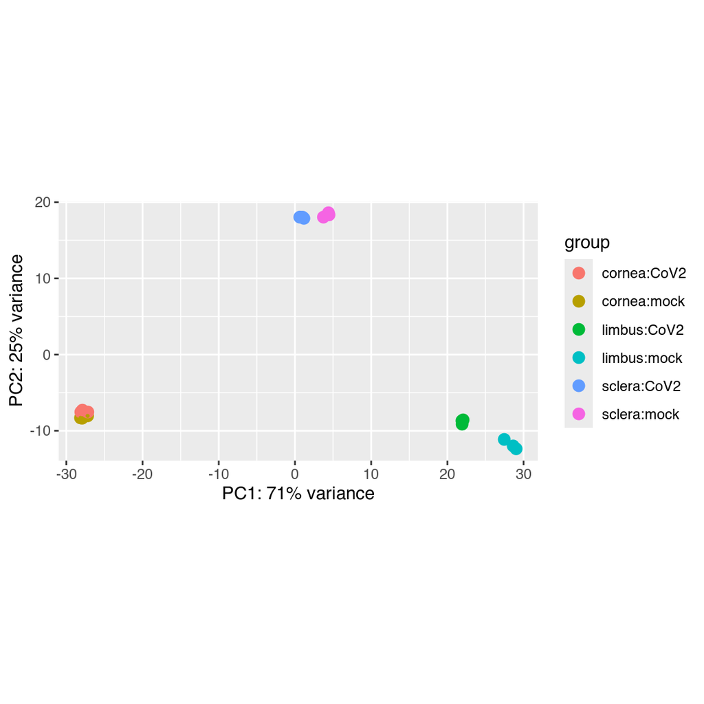

```r
plotPCA(vsd, intgroup=c("Tissue", "Condition")) +
    geom_point(size=0.5)
```

Again, we observe that the first PCA is mostly associated with tissue, although samples can also subcluster between the mock and CoV2 conditions.

## Differential expression

The standard DE is performed by the DESeq function.

```r
dds <- DESeq(dds)
```

```
using supplied model matrix
```

```r
dds
```

```
class: DESeqDataSet
dim: 14700 18
metadata(1): version
assays(5): counts mu H cooks originalCounts
rownames(14700): A1BG A1BG-AS1 ... ZZEF1 ZZZ3
rowData names(23): baseMean baseVar ... maxCooks replace
colnames(18): MW1 MW2 ... MW17 MW18
colData names(4): Tissue Condition sizeFactor replaceable
```

```r
resultsNames(dds)
```

```
[1] "Intercept"     "ConditionCoV2"
```

[output not shown]

```r
res <- results(dds, name="ConditionCoV2") # This function provides the lof2Fold Changes and p-values for a given coefficient name
res
```

```
log2 fold change (MLE): ConditionCoV2
Wald test p-value: ConditionCoV2
DataFrame with 14700 rows and 6 columns
          baseMean log2FoldChange     lfcSE      stat    pvalue      padj
         <numeric>      <numeric> <numeric> <numeric> <numeric> <numeric>
A1BG       90.4475     -0.1439495  0.118021 -1.219695  0.222581  0.803126
A1BG-AS1  278.3007     -0.0480946  0.112076 -0.429126  0.667832  0.963881
A2M       873.3212     -0.8092580  0.741401 -1.091525  0.275042  0.833286
A2M-AS1    11.3404      0.4892287  0.256631  1.906348  0.056605  0.531853
A4GALT    775.8491      0.1133252  0.223626  0.506761  0.612322  0.951852
...            ...            ...       ...       ...       ...       ...
ZYG11A     17.6651     -0.3825263 0.3813743 -1.003021  0.315851  0.855794
ZYG11B   1385.1616      0.0993295 0.1068925  0.929246  0.352761  0.874910
ZYX      6722.2007     -0.2497730 0.1098916 -2.272903  0.023032  0.359851
ZZEF1    1364.0281      0.1296682 0.0923057  1.404769  0.160090  0.741104
ZZZ3     1187.3067      0.1200589 0.0744052  1.613582  0.106618  0.661463
```

Then, a results table can be generated. In this case, we provide a value in the ‘name’ argument in the results function, which correspondds to the CoV2 effect encoded in our design matrix. We will also explore other ways to access results in the follow up sections.

## Log-Fold shrinkage

Shrinkage of the log-fold changes estimates is recommended for visualization and ranking of genes.

```r
resLFC <- lfcShrink(dds, coef="ConditionCoV2", type="apeglm")
```

```
using 'apeglm' for LFC shrinkage. If used in published research, please cite:
    Zhu, A., Ibrahim, J.G., Love, M.I. (2018) Heavy-tailed prior distributions for
    sequence count data: removing the noise and preserving large differences.
    Bioinformatics. https://doi.org/10.1093/bioinformatics/bty895
```

The lfcShrink has various shrinkage methods, here we will use apeglm. Again, we look for the CoV2 effect model by setting up the coef argument in the lfcShrink function.

### MA plots

Let’s compare the MA plots between the shrunken FC and the regular FC.

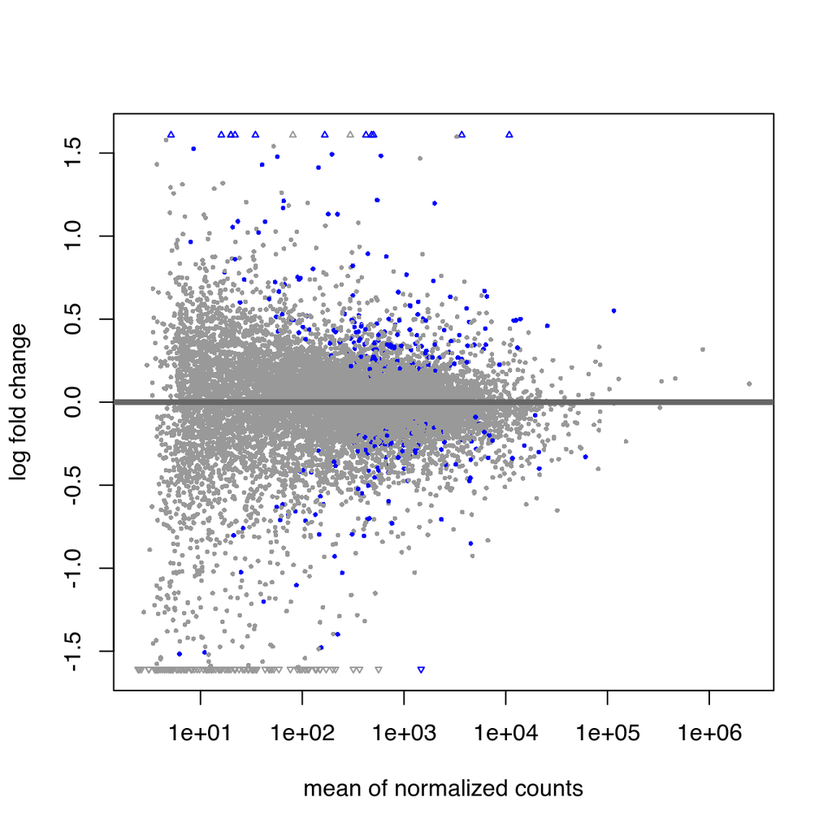

```r
plotMA(res)
```

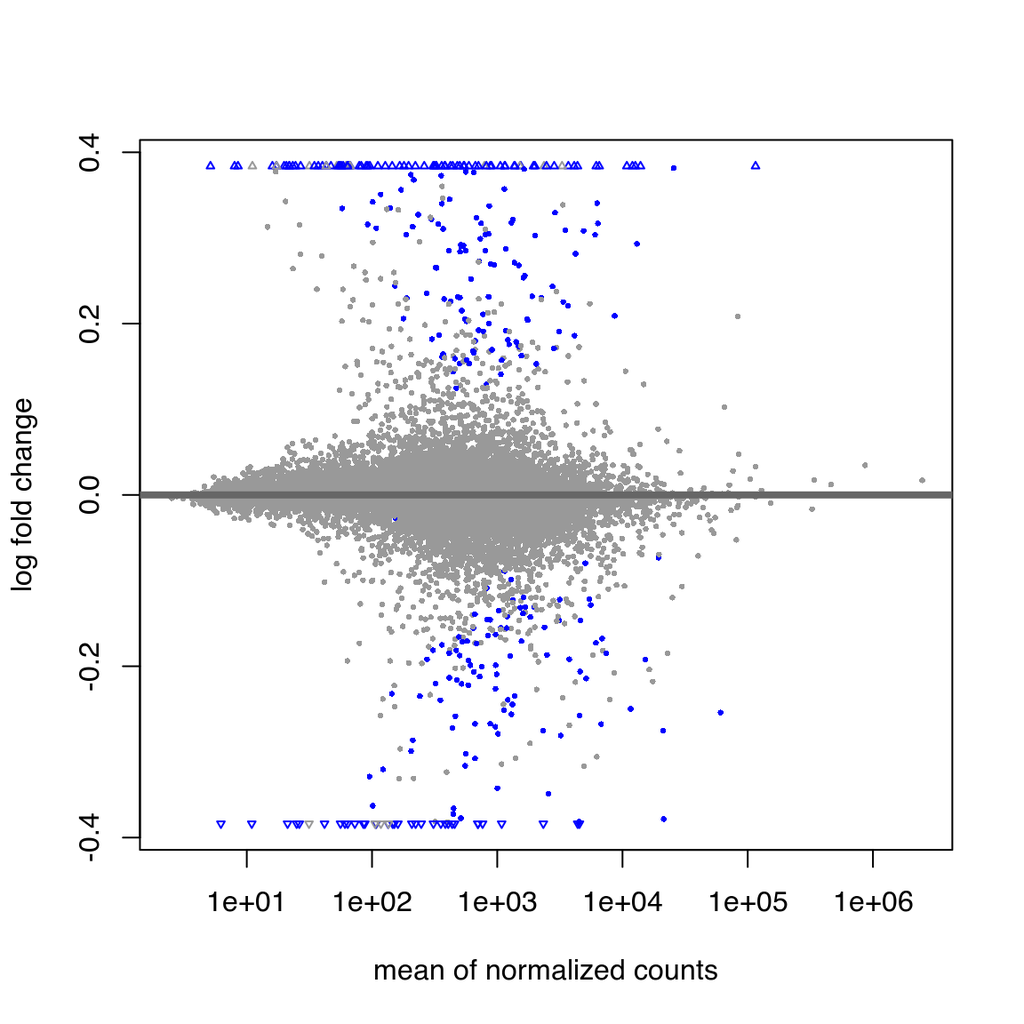

```r
plotMA(resLFC)
```

You can see that the shrunken log2 fold changes remove the noise associated with log2 fold changes from low count genes.

### Volcano plot

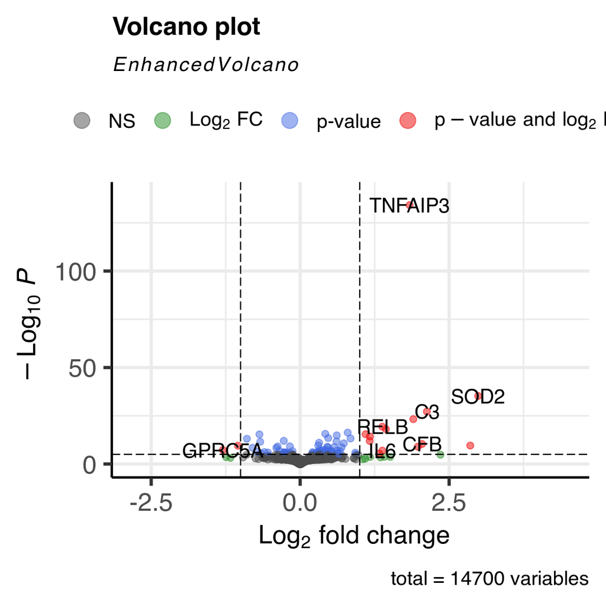

```r
EnhancedVolcano(resLFC,
                lab = rownames(resLFC),
                x = 'log2FoldChange',
                y = 'pvalue')
```

We can explore also the results using a Volcano Plot.

### Plot counts

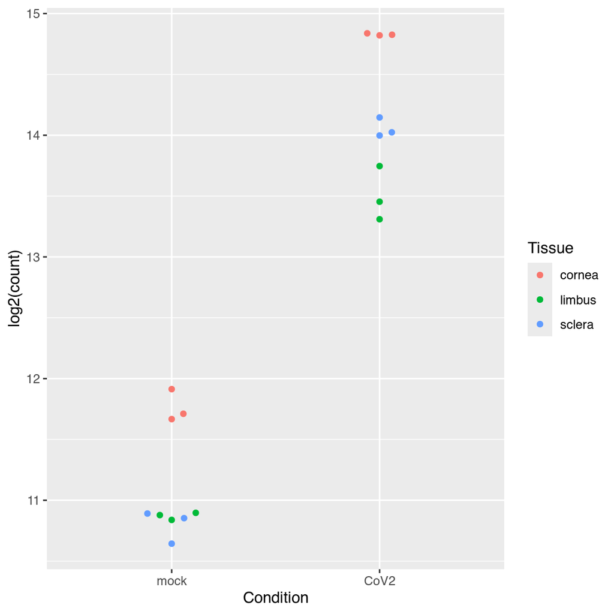

```r
geneCounts <- plotCounts(dds, gene = "SOD2", intgroup = c("Condition","Tissue"),returnData = T)
ggplot(geneCounts, aes(x = Condition, y = log2(count), color = Tissue)) +  geom_beeswarm(cex = 3)
```

We can also plot the normalized count values for a given gene.

### Heatmaps

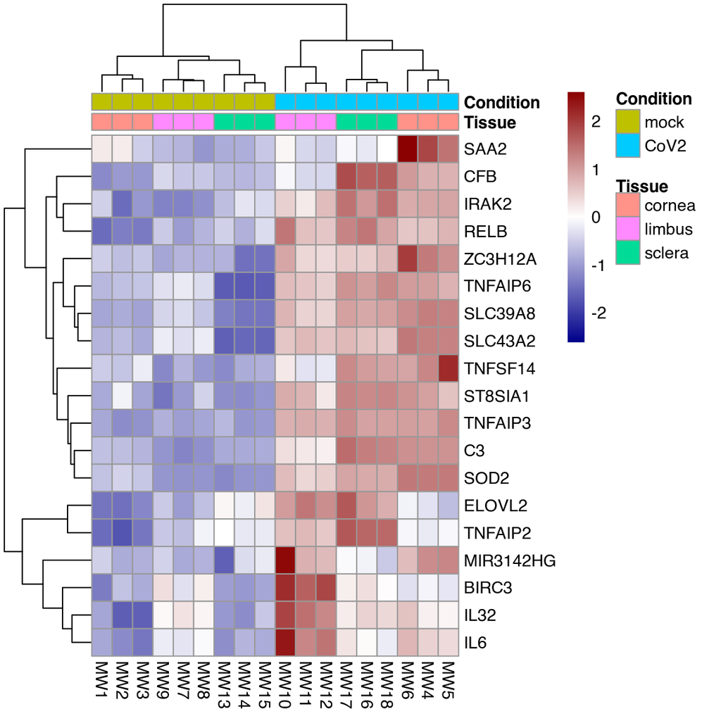

```r
sig_genes<- rownames(resLFC[with(resLFC, abs(log2FoldChange > 1) & padj < 0.05),])
colors <- colorRampPalette(c("darkblue","white","darkred"))(255)
pheatmap(assay(vsd[sig_genes,]), annotation_col=meta,col=colors, scale="row")
```

Finally, we can generate a heatmap for a subset of genes with significant DE changes (padj < 0.05 and log2FoldChange >1).